# Selection - The Basics

November 15 2017

Lesson based on materials from [Bruce Cochrane](http://www.teachingpopgen.org)

```r
library(TeachingPopGen)
```

### Background

Natural Selection is, of course, the basis for the Darwinian theory of evolution, and perhaps surprisingly, it is something we have barely touched upon up to this point. The reason for that is important - without first having a thorough understanding of the stochastic processes of drift, mutation and so forth, it is difficult if not impossible to infer the action of selection in any definitive way. So having done that, we now want to look at the genetics of selection; in so doing, we will follow address the following three questions:

1. Taken by itself, how do we expect selection to affect allele and genotype frequency dynamics?
2. At a theoretical level, how should selection, mutation and drift interact?
3. Given that theoretical basis, how can we identify the effects of selection based on molecular sequence data?

### Fitness

Fitness is, broadly speaking, the contribution made by an individual to the subsequent generation, as measured by numbers of viable and fertile progeny. For our purposes, of course, since we are interested in allele frequency dynamics in diploid population, what we really want to be considering is the contributions made by individuals of a given genotype. In doing so, there are a couple of considerations we need to take into account

#### Fitness components

Numerous factors contribute to fitness, among them

1. **Fertility**. In order to contribute to subsequent generations, an individual has to be capable of producing viable gametes.
2. **Mating success**. Having produced those gametes, s/he needs to mate successfully.
3. **Viability of progeny** Having mated, the resulting embryos must survive to reproductive age
4. **Fertility of progeny** And finally, those reproductive age progeny have to themselves be fertile

In fact, there are many more elements that can be examined; we are going to restrict most of our attention to viability as a measure of fitness, briefly considering fertility as somewhat of a special case.

#### Absolute vs. relative fitness

In our simple formulation, fitness is measured by the average number of progeny produced by individuals of a particular genotype. But, just as we did when we first developed Hardy-Weinberg theory, we need to be able to use those numbers to generate expectations about frequencies, both of genotypes and alleles.

Consider the following example. We are looking at a mouse coat color polymorphism, with two alleles, C and R:

```r
fC <-.3
fR <-.7
```

Furthermore, based on experimental observation, we observe that the viabilities of the three genotypes are as follows:

```r
wCC <-.5
wCR <- .4
wRR <- .3
w <-c(wCC,wCR,wRR)
```

Now, suppose we have a population of 100,000 newborn mice (before selection has occurred) and the population is in Hardy-Weinberg equilibrium. That would mean that we would have the following numbers of inviduals.

```r
N <-100000
Ngenos.pre <-c(fC^2,2*fC*fR,fR^2)*N
Ngenos.pre
```

```
## [1]  9000 42000 49000
```

But, as they mature, the viability differences come into play, at reproductive age, the numbers become

```r
Ngenos.post <-Ngenos.pre*w
N.post <- sum(Ngenos.post)
Ngenos.post
```

```
## [1]  4500 16800 14700
```

```r
N.post
```

```
## [1] 36000
```

Note a couple of things here. First, whereas initially there were 100000 embryos, after selection, there are only 36000 adults. If we take the ratio of those two values, we get the **mean fitness** of the population

```r
wbar <-N.post/N
wbar
```

```
## [1] 0.36
```

And note that the two factors that contribute to that are the genotype frequencies in the embryos (determined by the allele frequencies of the parents) and the viabilities of the those embryos as determined by their genotypes.

We can now ask the usual questions - is this new, post-selection, population of mice in Hardy-Weinberg equilibrium, and what are the allele frequencies? We will use our old hw function to do those calculations:

```r
hw.post <-hw(Ngenos.post)
```

```
## [1] p= 0.358333333333333 q= 0.641666666666667
##        obs   exp
## [1,]  4500  4622
## [2,] 16800 16555
## [3,] 14700 14822
## [1] chi squared = 7.885 p =  0.005 with 1 d. f.
## [1] F =  -0.0148
```

And our answers are

1. No, they are not in Hardy Weinberg equilibrium, and
2. The allele frequencies have changed. Whereas our starting frequency of the C allele was .3, we now see that it is .358.

But let’s look at another scenario. Suppose we repeat the above, only now assume that selection is 10 times more intense, that is that the viabilities of the three genotypes are .05, .04, and .03. We can repeat the same calculations as above:

```r
w <-c(.05,.04,.03)
Ngenos.post <-Ngenos.pre*w
wbar <-sum(Ngenos.post/Ngenos.pre)
wbar
```

```
## [1] 0.12
```

```r
Ngenos.post
```

```
## [1]  450 1680 1470
```

```r
hw(Ngenos.post)
```

```
## [1] p= 0.358333333333333 q= 0.641666666666667
##       obs  exp
## [1,]  450  462
## [2,] 1680 1655
## [3,] 1470 1482
## [1] chi squared = 0.788 p =  0.375 with 1 d. f.
## [1] F =  -0.0148
```

```
## $Observed
## [1]  450 1680 1470
##
## $Expected
## [1]  462.25 1655.50 1482.25
##
## $Allele_freqs
## [1] 0.3583333 0.6416667
##
## $Chisq
## [1] 0.7884539
##
## $prob
## [1] 0.374568
##
## $F
## [1] -0.01479915
```

And we see that the allele frequency change that results is identical to what we saw previously (although now there is not a significant difference from Hardy-Weinberg expecations in the genotype frequencies). This leads to an important point - **It is the fitness of genotypes relative to those of others, that is important, as opposed to the absolute magnitudes of those fitnesses.**.

So from here on out, we will work with relative fitnesses, defined as follows. One genotype, usually that one with the highest absolute fitness, will be assigned a relative fitness of 1, and the others some values 1-s and 1-t, where s and t, the selection coefficients, reflect the intensity of selection and assume values between 0 and 1.

### A more general approach

We can easily create a general model of selection thusly:

w(AA) = 1  
w(Aa) = 1-hs  
w(aa) = 1-s

Having done so, we can then show that

Δp = p(w<sub>A</sub> - w)/w

Where w<sub>A</sub> is the mean fitness of individuals with an A allele (homozygote or heterozygote) and w is the mean fitness of the population

Where mean fitness can be calculated as

$$\bar w = p^2w_{AA} + 2pqw_{Aa} + q^2w_{aa}$$

or we can also calculate Δp like so:

$$\Delta p = \frac{pq[p(w_{AA}-w_{Aa})-q(w_{aa}-w_{Aa})]}{\bar w}$$

The following R code implements that equation. It takes as inputs the initial value of p, the values of h and s, and whether or not a plot is to be returned. The default function returns a vector with the values of p.

```r
deltap <-function(pinit,h,s,plot=FALSE){

p <-c(pinit,rep(0,99))
dpg <-c(0,rep(0,99))
for(i in 2:100){
pt <-p[i-1]
qt <-1-pt
wbar <-1-(2*pt*qt*h*s)-s*qt^2
dp<- ((pt*qt*s)*(pt*h+qt*(1-h)))/wbar
p[i] <-pt+dp

 }
p2 <- seq(0,1,.01); q2 <-1-p2
wbar2 <- 1-(2*p2*q2*h*s)-s*q2^2
dp2<- ((p2*q2*s)*(p2*h+q2*(1-h)))/wbar2
if(plot){
par(mfrow=c(1,2))
print(dp2)
plot(p, type="l", ylab="p", xlab="Generation", ylim=c(0,1),col="blue", main="Allele Frequencies vs. time")
lines(1-p,col="red")
plot(p2,dp2,type="l",xlab="p",ylab="Delta p", xlim =c(0,1), main="Delta(p) vs. p")
}
p

}
```

#### Selection against a deleterious recessive

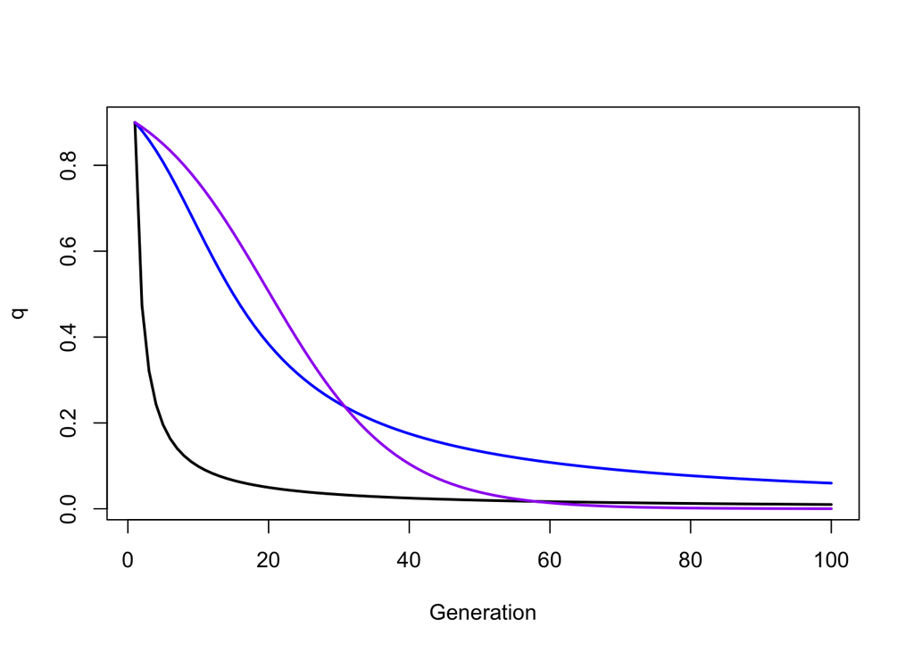

```r
out <- deltap(pinit=.1,h=0,s=1)
plot(1-out,type="l",xlab="Generation",ylab="q",lwd=2,cex=1.5)
lines(1-deltap(.1,0,.2,plot=FALSE), col="blue",lwd=2,cex=1.5)
lines(1-deltap(.1,.5,.2),col="purple",lwd=2,cex=1.5)
```

Now, what if we had weaker recessive selection, say with s=.1?

```r
plot(1-deltap(pinit=.1,h=0,s=.1,plot=FALSE), col="blue")
```

[output not shown]

And we see that, as expected, while q declines, is does so much more slowly. But now let’s add in selection against the heterozygote as well, setting h to .5 (meaning that the fitness of the heterozygote is intermediate to that of the homozygote.

```r
lines(1-deltap(pinit=.1,h=.5,s=.1),col="purple")
```

The differences, while present, are not spectacular. But what about rates of change? After all, that is what determines the rate of evolution. We can look at that with the same function, only now setting the plot flag to TRUE.

First, the lethal case:

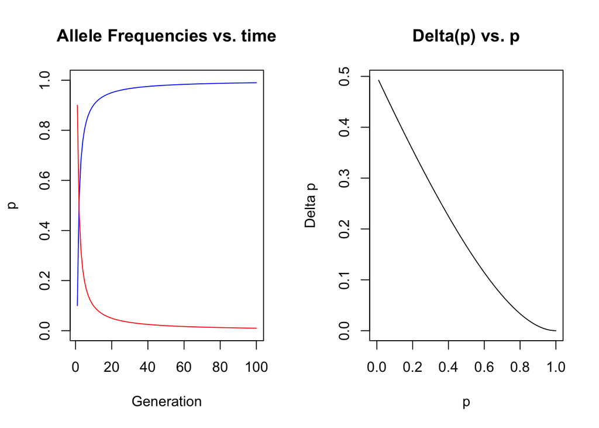

```r
x <-deltap(pinit=.1,h=0,s=1, plot=TRUE)
```

And we see that, as p increases, Δp declines, meaning that when *a detrimental allele becomes rare, selection becomes inefficient*.

Now let us suppose that s=.1, as above

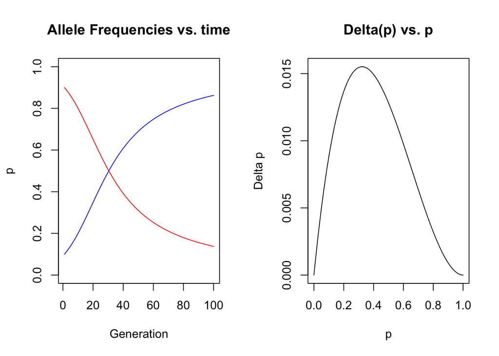

```r
deltap(pinit=.1,h=0,s=.1,plot=TRUE)
```

How do we explain this? as p increases from zero, selection becomes more effective, as the number of AA and Aa genotypes(with a fitness of 1) increases, however, as aa individuals become rare, the efficiency declines.

Finally, if we set the fitness of the heterozygote to be intermediate to that of the two homozygotes:

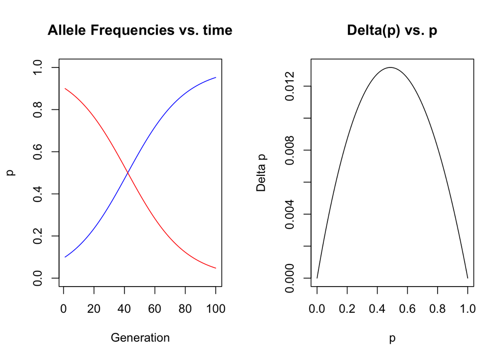

```r
deltap(pinit=.1,h=.5,s=.1,plot=TRUE)
```

Now we see that delta p is maximized when p=.5 . Of course, we know from Hardy-Weinberg theory that this is when heterozygotes are most common, and since selection in this case is acting on them, this result is as expected.

#### A special case - heterozygote advantage

All of the above have been examples of directional selection, with one allele or the other ultimately going to fixation. But what about the case of heterozygote advantage? The classical example of this is malaria and sickle-cell anemia, where heterozygotes for the diseased allele have resistance to malaria infection.

For example, suppose that w have the following:

w(AA) = 1-s  
w(Aa) = 1  
w(aa) = 1-t

And as an example, suppose that s=.4 and t=.3. To use our function, we need to do some algebra to normalize relative fitnesses to that of AA, but when we do, we find that s=-.166 and h=4, so we can plug those into our function and we get

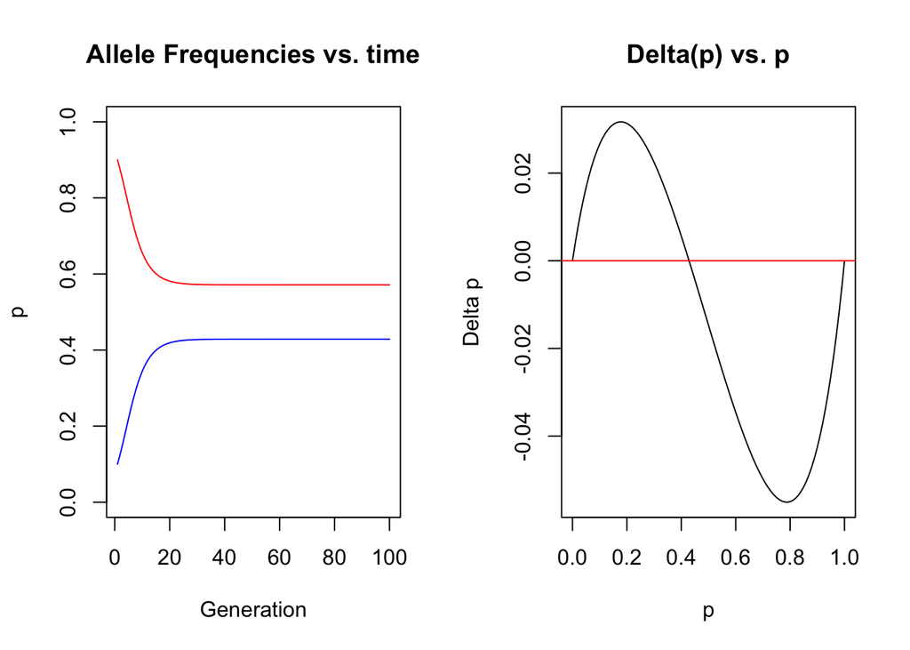

```r
deltap(pinit=.1,h=4,s=-.16,plot=TRUE)
abline(h=0,col="red")
```

There are two things to note. First of all, as expected, we see that there are nonzero equilibrium values for both p and q - after all, heterozygotes have the maximum fitness. This means that there are three equilibrium points in the δp vs. p curve, when p=0, p=1, or when p and q are at their equilibrium values.

But what is that mean fitness? We can calculate it as follows:

```r
p <-(.3/(.4+.3))
q <-1-p
wbar <-p^2*0.3 + 2*p*q*1 + q^2*0.4
wbar
```

```
## [1] 0.6755102
```

And we see that it *the mean fitness of the population is less than 1*. Thus, the good news about heterozygote superiority is that it maintains variation. The bad news? At a cost to population fitness. We will address that more in the future.

### Calculation of fitness from real data

To quickly summarize, we have been focusing on one component of fitness (viability) and modeling the impact of various models on allele frequency dynamics. In so doing, we have defined relative fitness, mean fitness, and selection coefficients and shown that, by itself, only heterozygote advantage leads to a stable polymorphism (at a cost in mean fitness). However, other than the hypothetical example we started our discussion with, we have not addressed how we might estimate fitness parameters from real data. In fact, this is something that is often difficult to do, especially when selection coefficients are small. However, it is not impossible.

This example involves sickle cell anemia and goes from observed genotypes in a large sample of adults to an estimate of relative fitnesses of the three genomes. The approach is based on observed departure from Hardy Weinberg in those adults **and the assumption that that deviation is the result of viability differences among the three genotypes**.

#### Hardy-Weinberg Calculations

To start with, we can calculate the allele frequencies from the observed adult population and use them to determine the **expected** genotype distribution:

```r
genos.n <-c(25374,5482,67)
genos.f <-round(genos.n/sum(genos.n),3)
p <-genos.f[1]+.5*genos.f[2]
genos.exp <-round(c(p^2,2*p*(1-p),(1-p)^2),3)
genos <-rbind(genos.f,genos.exp)
rownames(genos) <- c("Observed","Expected")
round(genos,30)
```

```
##           [,1]  [,2]  [,3]
## Observed 0.821 0.177 0.002
## Expected 0.827 0.165 0.008
```

We can then ask if the differences between observed and expected are significant:

```r
hw(genos.n)
```

```
## [1] p= 0.909193803964687 q= 0.0908061960353135
##        obs   exp
## [1,] 25374 25562
## [2,]  5482  5106
## [3,]    67   255
## [1] chi squared = 167.655 p =  0 with 1 d. f.
## [1] F =  -0.0736
```

```
## $Observed
## [1] 25374  5482    67
##
## $Expected
## [1] 25561.9838  5106.0324   254.9838
##
## $Allele_freqs
## [1] 0.9091938 0.0908062
##
## $Chisq
## [1] 167.6545
##
## $prob
## [1] 0
##
## $F
## [1] -0.07363204
```

And we see that in fact the chi-squared value is astronomical. So let’s proceed

#### Make some assumptions

In what follows, we make two assumptions:

1. Mating is random, so **at the time of zygote formation, HWE exists.**
2. Any observed departure from Hardy-Weinberg ratios in adults is due to egg-to-adult viability differences among genotypes

#### Calculate relative fitnesses

Given those assumptions there are two ways to proceed. First, we could assume that there was a pool embryos of some arbitrary size (larger than the number surveyed) in HW equilibrium, calculate the numbers of the genotypes in that pool and then calculate the ratio of observed individuals to those numbers to get the absolute fitness:

```r
embryos.n <-genos.exp*40000
embryos.n
```

```
## [1] 33080  6600   320
```

```r
w <-round(genos.n/embryos.n,3)
w
```

```
## [1] 0.767 0.831 0.209
```

And in keeping with our norm, we can calculate the values relative to the most fit genotype (which happens to be the heterozygote)

```r
w <- round(w/max(w),3)
w
```

```
## [1] 0.923 1.000 0.252
```

But there is actually an easier way to get the same answer. We have observed frequencies, we also have expected ones, so let’s just take the ratio of those two:

```r
w2 <-genos.f/genos.exp
w2 <-w2/max(w2)
round(w2,3)
```

```
## [1] 0.925 1.000 0.233
```

And we get essentially the same answer.

#### Summary

This is a classic textbook type of calculation. However, in addition to the assumptions we’ve already described, notice the magintude of the selecton coefficients:

```r
s <- 1-w[1]
t <-1-w[3]
s;t
```

```
## [1] 0.077
```

```
## [1] 0.748
```

*Both of these are very large*. And remember, the calculation is based on observed departure from HW. In cases where selection coefficients are smaller (as is typical in most cases of polymorphisms), the departure from HW in a reasonable sample size is likely to be insignificant, rendering this sort of calculation suspect at best.

### Mutation-Selection Equilibrium

In our discussion thus far, we have used selection as the only factor affecting allele frequencies. Of course, in an ideal population, we also have to consider mutation. First, let’s consider a recessive detrimental allele. The loss due to selection will be q<sup>2</sup> * w(AA), or q<sup>2</sup> * (1-s). Since q<sup>2</sup> ≈ 0, we can approximate this as -sq<sup>2</sup>. If the gain due to mutation is μ , then equilibrium will be reached when

μ = sq<sup>2</sup>

or

q <- √ (μ/s)

As an example, we can look at some reasonable numbers - µ=10<sup>-7</sup>, s=.01

```r
u <-10^-7
s <-.01
q1 <-sqrt(u/s)
q1
```

```
## [1] 0.003162278
```

So at equilibrium, we would expect an allele frequency of 0.0031623, which is small but not insignificant. We can also look at a range of values of s:

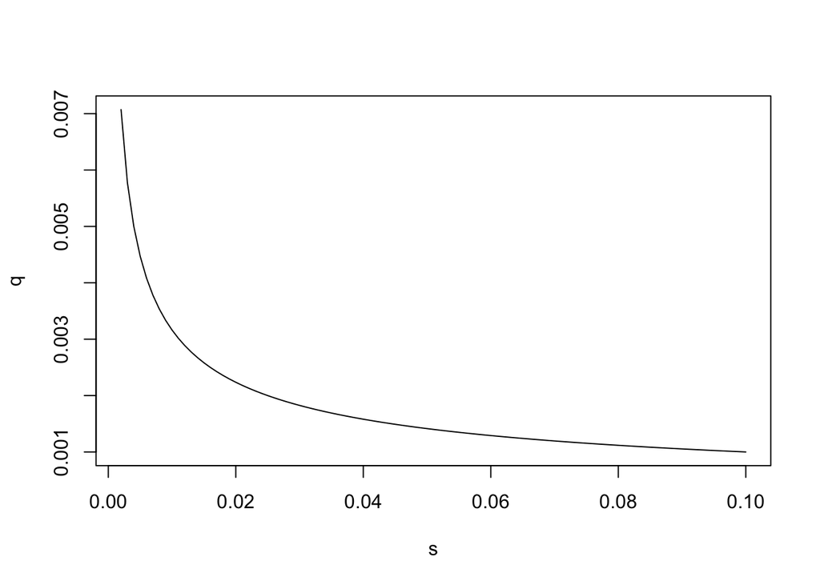

```r
par(mfrow=c(1,1))
s <-seq(.002,.1,.001)
q <-sqrt(u/s)
plot(s,q,typ="l")
```

But now let’s assume that selection also acts against the heterozygote. We can proceed as follows:

1. If q is small, then we can treat the number of aa homozgyotes as zero
2. And in that case, p is nearly 1, so we can approximate the frequency of heterozygotes as 2q.

Thus, the reduction in the number of heterozygotes, using our previously established notation, will be 2qsh; with respect to little a alleles (half of those in the heterozygotes) it will be qsh. And, of course, once again, the gain due to mutation will be μ thus at equilibrium

µ = hsq

and

q = µ/hs

So let’s see what we get, keeping s at .01 but now adding in a weak effect (h=.1) on the heterozygote:

```r
h=.1
s <-.01
q2 <-(u/(h*s))
q2
```

```
## [1] 1e-04
```

And comparing that with what we got above for the purely recessive case:

```r
q2/q1
```

```
## [1] 0.03162278
```

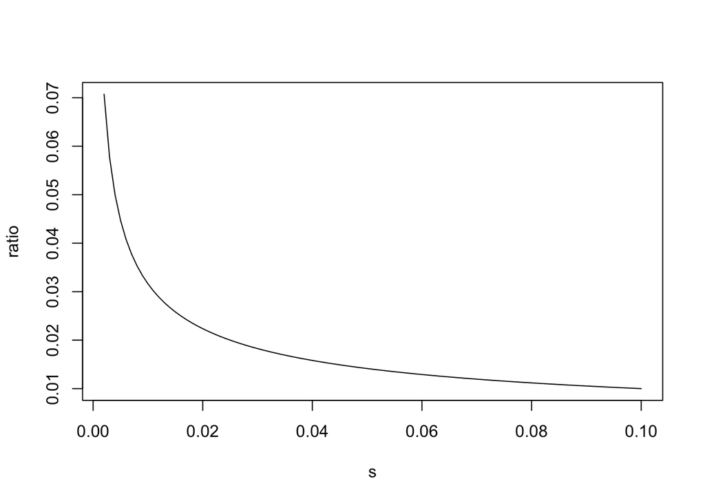

```r
s <-seq(.002,.1,.001)
q1 <-sqrt(u/s)
q2 <-u/(h*s)
plot(s,q2/q1,type="l",xlab="s",ylab="ratio")
```

And this makes a biologically important point. The equilibrium frequency of a detrimental allele is much lower when selection acts even weakly on the heterozygote as well as the homozygote.

This work is licensed under a [Creative Commons Attribution-NonCommercial-ShareAlike 4.0 International License](http://creativecommons.org/licenses/by-nc-sa/4.0/deed.en_US).

### Detecting Selection in DNA sequence data

So now we need to think more closely about what DNA does. Historically, the definition of a gene was that portion of DNA that encodes a particular polypeptide, and since much of molecular population genetic theory developed in the era of protein polymorphism studies, many of the classical tests of selection involve analysis of protein coding regions. We will start by looking at a few of them; we will then move on to see how the comprehensive nucleotide polymorphism data that are available to us today allow us to broaden our scope to include all DNA sequences, coding or other.

Before we explore this question, remember that we have already explored two for departure from neutral expecations - Ewens-Watterson and the Tajima test. However, these both suffer from two shortcomings. First, they are relatively insensitive - only in the most extreme cases do the test statistics differ greatly from neutral expectations. Second, if deviation is observed, there can be multiple explanations, and the role of selection (directional or balancing) is only one of them.

### Remember the genetic code

To quickly summarize, the genetic code has the following properties:

1. It’s a triplet code - 3 nucleotides encode 1 amino acid
2. All 64 possible triplets used; 3 are terminators but 61 in fact code for amino acids
3. Thus, the code is generate - more than one codon encodes one amino acid.
4. With the exception of first position in leu, arg and ser, all of the degeneracy is in third (wobble) position.

So let’s think about evolutionary change in this context. Suppose all mutations, (synonymous or nonsynonymous) are neutral, something that we assumed when we developed the Jukes and Cantor model for estimating rates of substitutions. If so, then if we calculate d for both classes, the expectation is that they should be equal, or dN=dS.

So what do we see? First, in a sample of 16 eukaryotic genes, we find that dN=.88 and dS = 4.65. So if we compute the ratio, we get the following

```r
.88/4.65
```

```
## [1] 0.1892473
```

So what this says is simply that the number of nonsynonymous substitutions is lower than that of synonymous. Since there is no question that some substitutions will have detrimental effects on protein function, while the effect of the average syonymous one will be minimal, this result should not be suprising. What we need to do, as always, is to look for those cases in which dN/dS for a particular gene or region differs from that of protein coding regions of the genome as a whole.

To do so we can examine a case in which there are *a priori* reasons to believe that selection might be playing a role. What about in a rapidly evolving pathogen like influenza?

```r
.0025/.01
```

```
## [1] 0.25
```

And while the ratio is a bit higher than for the random sample of genes, the difference is not impressive.

There is, however, one classic case in which this simple approach was much more informative. Hughes and Nei (1988) looked at sequence variation in the MHC loci in humans. These are proteins in the immune system that are involved in antigen recognition, and much is known about their structure vis-a-vis that function. So therefore, it was possible to examine both the antigen recognition domain, likely affected by selection, and compare it with other regions not involved in that function. The basic design of the experiment was as follows:

1. Collect 12 sequences for Class 1 alleles at HLA-A,HLA-B, and HLA-C
2. Calculate mean dN and dS for all pairwise combinations by loci
3. Subdivide by Antigen recognition sites, remainder of coding region

The results can be showed as follows:

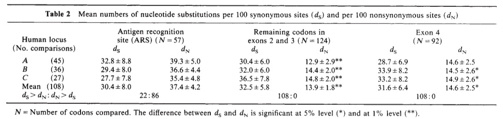

MHC

The high level of nonsynonymous substitution in the antigen-recognition region clearly suggests positive selection for amino acid substitutions, consistent with what would be expected - variation in this region provides the ability to recognize multiple antigens and thus adapt to a variable or changing pathogen environment.

### Going one step further - incorporating interspecific comparison

Up until this point, we have restricted ourselves almost exclusively to analysis of data obtained from a single species. But there is another aspect of the neutral theory we consider. As Kimura suggested in his 1971 classic paper, one way of thinking of protein polymorphsims within species is as simply a step on the path to between species differentiation. If that is the case, then if we compare dN/dS ratios among polymorphic sequences withiin a species, they should be comparable to what we observe when we make comparisons between closely related species (remembering, of course, to use a mutation model to correct for multiple hits on a single site). We will look at two tests that have been developed based on this logic, one briefly and one in some detail.

#### The HKA test

Hudson, Kreitmand and Aguade(1987) took the following approach. First, they asked what factors determine polymorphism and divergence. In brief, they are

1. Time since divergence
2. Effective population size of two species
3. The mutation and substitution rates for the gene or genes in question

And we can also note regarding these, that

1. The first two factors are population/species parameters, so they will be the same for any gene comparison we choose to make.
2. The third factor certainly does vary among genes. However, if indeed polymorphism is simply a transitional step in the divergence process, and the mutation rate is constant for a given gene, then *the ratio between variation and divergence should be the same for every gene*.

Hudson et al applied the method to data from the Alcohol dehydrogenase locus (ADH), as well as what was thought to be a noncoding flanking region, using polymorphism data from *Drosophila melanogaster* and divergence data from *D. melanogaster* and *D. sechellia*. To avoid the confounding effects of amino acid substitutions, they limited their treatment to noncoding sites. Their results showed that

1. Divergence between species is similar for the two genes.
2. Within-species variation (polymorphism) is much higher for Adh than for the flanking region - significant based on comparison to neutral expectations.

Hudson et al concluded that these results were consistent with the hypothesis that the Adh locus is subject to balancing selection within *D. melanogaster*, resulting in the high level of within-species polymorphism that was observed.

Note that we are assuming flanking region is neutral, and that may or may not be the case. In addition, we have restricted our consideration to noncoding substitutions, thus ignoring what we would expect to be a very important part of the picture. And finally, tests of significance involve fairly complicated simulations of neutral expectations. How can we address these problems?

#### [The McDonald-Kreitman Test](http://www.nature.com/nature/journal/v351/n6328/pdf/351652a0.pdf)

The MK test is probably the most widely used for evidence of selection in protein coding data. In essence, it combines the logic of dNdS testing with that of the HKA test, and it does so in a simple and straightforward fashion. It proceeds as follows:

1. Determine the number of silent and replacement polymorphisms within a gene and species of interest (Pn and Ps).
2. Determine the average number of substitutions (again silent and replacement) that have occurred between the species of interest and at least 1 sequence for one or more sibling species (applying JC or other correction as appropriate - Dn and Ds)
3. If indeed, as per Kimura, polymorphism is simply a stage of neutral evolution, then

Dn/Ds = Pn/Ps

The data that McDonald and Kreitman analyzed, once again for Adh, are as follows:

| Site Type | Divergent Between Species | Polymorphic Within Species |
| --- | --- | --- |
| Nonsynonymous | 7 | 2 |
| Synonymous | 17 | 42 |

Once again, polymorphism data were from *D. melanogaster*; substitution data (“fixed”) are based on comparison with two sibling species - *D. simulans* and *D. yakuba*.

So how do we go about analyzing this? Remember that what we want to know is whether the relationship of silent to replacement substitutions is the same for polymorphism within species and fixed divergence among species. In fact, we can do what is known as a contingency chi-square test to test this null hypothesis (note that McDonald and Kreitman used a G test, a more appropriate test, but which addresses the same question). In addition, we can calculate the following quantity:

FI = (Dn/Pn)/(Ds/Ps)

or alternatively

FI - (DnPs)/(DsPn)

Note that this the numerator is the divergence to polymorphism ratio for nonsynonymous changes, while the denominator is the same for synonymous ones. We could thus imagine the following scenarios:

1. If mutation is selectively neutral, the type of mutation doesn’t matter, and FI = 1
2. If substitutions between species are adaptive, then we would expect Dn/Pn >Ds/Ps, and thus FI >1
3. In the case of heterozygote advantage within species, then (based on the second formulation) Pn >Ps, making FI <1.
4. If most nonsynonymous mutations within species are detrimental, then again, we would expect to see Pn to be small and FI >1. However, we would also expect to see an excess of low-frequency derived alleles within species, which could allow us to distinguish this from possibility 2. We will return to this point in a bit.

The function MK does the above analysis The input for it is two vectors, consisting of the rows from the table above:

```r
MK(c(7,2),c(17,42))
```

```
## $Chi.squared
##
##  Pearson's Chi-squared test
##
## data:  tbl
## X-squared = 8.3373, df = 2, p-value = 0.01547
##
##
## $FI
## [1] 8.647059
```

But remember - there are two possible explanations for a value of FI greater than one - either directional selection occurring during speciation or purifying selection within species. Which is the case here? McDonald and Kreitman argued for the former - a number of adaptive mutations occurring in the lineages of the two species that lead to an excess of nonysnonymous substitutions. They argued against the alternative hypothesis on essentially parsimony grounds, arguing that the only scenario that could lead to these results is overly complex:

1. The species was historically small, so that weakly deleterious mutations are effectively neutral and thus subject to random fixation and loss. It would be those randomly fixed mutations that result in the observed value of Dn.
2. In *D.melanogaster* at least, subsequent to speciation, there was a population expansion, such that now those weakly deleterious alleles are subject to selection and thus reduced in frequency.

To quote them, “This slightly deleterious model requires so many assumptions about selection coefficients, population sizes and times of population expansions that we prefer the simpler explanation of the occasional fixation of an adaptive mutation.”

Note that, using the G test with a correction for small sample size, a more conservative approach, McDonald and Kreitman obtained similar results. Their conclusion, explained quite well in the paper, suggest that most of the replacements that have occurred are in fact adaptive, so that nonsynonymous polymorphisms, when they occur, have a short life time.

The basic mathematics of the test are extremely simple. In fact, if we look at the MK function

```r
MK
```

```
## function (NS, SS)
## {
##     options(warn = -1)
##     tbl <- rbind(NS, SS, correct = TRUE)
##     ch <- chisq.test(tbl)
##     FI <- ((NS[1]/NS[2])/(SS[1]/SS[2]))
##     list(Chi.squared = ch, FI = FI)
## }
## <environment: namespace:TeachingPopGen>
```

We see that it is little more than a call to the built-in function chisq.test. In addition, there are web sites that will do the calculation interactively - for example see [this one](http://turner.faculty.swau.edu/mathematics/math241/materials/contablecalc/entry.php).

### Summary

So we’ve seen that we can take three different approaches to the detection of selection, all of which involve, one way or another, a comparison of substitution rates and levels of polymorphism. Note, however, that, as described so far, we are, by and large, approaching the problem on a gene-by-gene basis. Ideally, we’d like to take a broader view, using available data to assess patterns of selection in the genome as a whole. In our next unit, we will begin to do that, using the MK statistic as a means to look for evidence of selection in the *Drosophila* genome.